## Wind Analysis Notebook

Version: 3

Updated 23 February 2020

### In this version:

- Created wind Magnitude index
  - Previously only had array of 1s and 0s denoted whether the wind magnitude was above or below 6
  - Now we have an array of values denoting the days below 6, as well as an array of values denoting events below 6
- To DO:
  - Finish annotating code
  - clean up code
  - Finish annotating w/ Markdown, providing a thorough description
  - define plotting functions to expedite the plotting process
  - Write new array for events >= 14 days in length
  - Get plot of event frequency per some time interval
  - add sea ice data to code
  - use same code and event indexes to look at events only over arctic regions

# Arctic Wind Analysis

Pat LaChapelle<sup>1,2</sup>  
Dr. Madison Smith<sup>1,3</sup>  
University of Washington Applied Physics Lab  
pgl3@uw.edu  
www.patlachapelle.us  
November 2019-current  
<sub>1 - University of Washington</sub>

## Overview

This Notebook is purposed for the documentation of my research conducted under the Supervision of Dr. Madison Smith (Applied Physics Lab). This project aims to investigate wind patterns in arctic regions as a method of determining feasibilities of prospective experiments in Dr. Smith's upcoming Arctic expedition. Published research suggests a correlation between sustained wind speeds below 6 m/s and increased temperature/decreased salinity in arctic open-water ice leads (Holland, 2003). The combination of higher temperature and lower salinity would lead to a higher differential of lateral ice melting while basal and surface melting would *hypothetically* remain constant. This change in lateral melt is unaccounted for in current climate models. Datasets included in this project are manipulated with xarray, a python package purposed for the creation and manipulation of large datasets.

## Reading in Wind Data

```python
'''
Begin Code
'''
#import necessary packages
import math
import netCDF4
import xarray as xr
import matplotlib
from matplotlib import pyplot as plt
import numpy as np
import pandas as pd
import cartopy.crs as ccrs
import cartopy
from matplotlib.colors import ListedColormap, LinearSegmentedColormap
import imageio
import os
#Finish Importation of Packages

#Clear up error in MatPlotLib, as required when importing the package
from pandas.plotting import register_matplotlib_converters
register_matplotlib_converters()
```

```python
'''
Begin Merging of Datasets
'''

#Set Desired Range of years
min_year=2010
max_year=2010

#Derive numyears variable
numyears=max_year-min_year+1

#set file path for vwind
Vwindfilepath='WindVelocities/Vwind/vwnd.10m.gauss.'

#create dictionary for vwind of each year
DSV=['']*numyears

#Set file path for uwind
Uwindfilepath='WindVelocities/Uwind/uwnd.10m.gauss.'

#create dictionary for Uwind for each year
DSU=['']*numyears

#set file extension of netCDF4 files & create year dict
fileext='.nc'
year=['']*numyears

#loop for combining datasets
for x in range(numyears):
    year[x]=str(min_year+x)

    DSV[x]=xr.open_dataset(Vwindfilepath+year[x]+fileext)


    DSU[x]=xr.open_dataset(Uwindfilepath+year[x]+fileext)

    if x==0:
        FullWind=xr.merge([DSV[x],DSU[x]])
    else:
        FullWind=xr.merge([FullWind,DSV[x],DSU[x]])

    if year[x]==str(max_year):
        break


    DSV[x].close()
    DSU[x].close()

#Save Wind dataset as netCDF4 file
FullWind.to_netcdf('WrittenDatasets/FullWind.nc')

#Close wind dataset
FullWind.close()

#delete unnecessary variables
del year, fileext, DSV, DSU, x, Vwindfilepath, Uwindfilepath, min_year, max_year, numyears, FullWind

#End Merging of Datasets
```

## Isolating Summer Data

Our primary interest lies in Summer data, which can be easily isolated using time indexing in xarray.

```python
#Open saved FullWind dataset
FullWind=xr.open_dataset('WrittenDatasets/FullWind.nc')

#merge Summer Month arrays to make FullWind for summer
FullWind=xr.merge([FullWind.where(FullWind.time['time.month']==4, drop=True), FullWind.where(FullWind.time['time.month']==5, drop=True), FullWind.where(FullWind.time['time.month']==6, drop=True), FullWind.where(FullWind.time['time.month']==7, drop=True), FullWind.where(FullWind.time['time.month']==8, drop=True)])

#Save FullWind dataset
FullWind.to_netcdf('WrittenDatasets/FullWind.nc')

#close dataset
FullWind.close()

#Display the months in the Dataset
with xr.open_dataset('WrittenDatasets/FullWind.nc') as ds:
    print(ds.time.dt.month)

del FullWind
```

```
<xarray.DataArray 'month' (time: 153)>
array([4, 4, 4, 4, 4, 4, 4, 4, 4, 4, 4, 4, 4, 4, 4, 4, 4, 4, 4, 4, 4, 4,
       4, 4, 4, 4, 4, 4, 4, 4, 5, 5, 5, 5, 5, 5, 5, 5, 5, 5, 5, 5, 5, 5,
       5, 5, 5, 5, 5, 5, 5, 5, 5, 5, 5, 5, 5, 5, 5, 5, 5, 6, 6, 6, 6, 6,
       6, 6, 6, 6, 6, 6, 6, 6, 6, 6, 6, 6, 6, 6, 6, 6, 6, 6, 6, 6, 6, 6,
       6, 6, 6, 7, 7, 7, 7, 7, 7, 7, 7, 7, 7, 7, 7, 7, 7, 7, 7, 7, 7, 7,
       7, 7, 7, 7, 7, 7, 7, 7, 7, 7, 7, 7, 8, 8, 8, 8, 8, 8, 8, 8, 8, 8,
       8, 8, 8, 8, 8, 8, 8, 8, 8, 8, 8, 8, 8, 8, 8, 8, 8, 8, 8, 8, 8],
      dtype=int64)
Coordinates:
  * time     (time) datetime64[ns] 2010-04-01 2010-04-02 ... 2010-08-31
```

## Creating a Mask for the Data

Given that we are investigating the wind reanalysis data for purposes related to sea ice, it is necessary to mask data over land as wind speeds interact differently with land than they do with open ocean/sea ice. To do this, we will use the high resolution land/sea mask provided with NCEP/NCAR data, which has a resolution of 720 latitude coordinates, and 1440 longitude coordinates.

This mask is rotated from the actual values by 180 degrees longitude (see below)

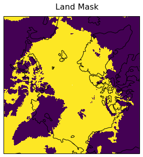

```python
#----------------------------
#Begin Mask
#open Mask
ls_mask=xr.open_dataset('LandSeaMasks/lsmask3.nc')

#remove time coordinate
ls_mask=ls_mask.squeeze()

#Set the mask as the wtp variable ('What to plot")')
wtp=ls_mask.lsmask

#End Mask
#-----------------------------
#-----------------------------
#Begin Plot
#Create fig, set title, etc.
fig=plt.figure(figsize=[10,5])
fig.suptitle('Land Mask', x=0.527, y=0.95, fontsize=16)
ax=plt.axes(projection=ccrs.NorthPolarStereo(180,0))
ax.set_extent([0, 358.125, 65, 90], crs=ccrs.PlateCarree())
ax.imshow(wtp, transform=ccrs.PlateCarree())
ax.coastlines()

#close dataset
ls_mask.close()

#Deleter Variables`
del wtp, ls_mask

#save the plot
plt.savefig('Plots/Maps/InitialMask.png', bbox_inches='tight')

#display plot
plt.show()
#End Plot
#-------------------------------
```

### Adjusting the Mask

See how Greenland is off by 180 degrees? We can fix this by using the roll command in numpy, which rotates the values about a selected axis.

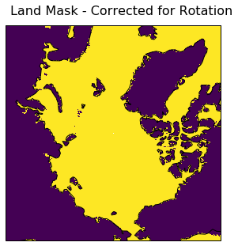

```python
#--------------------------------------
#Loading and altering mask
#open Mask
ls_mask=xr.open_dataset('LandSeaMasks/lsmask3.nc')
ls_mask=ls_mask.squeeze()
#ls_mask=ls_mask.where(ls_mask.lat >= 65, drop=True)

#Rotate mask
rotated=np.roll(ls_mask.lsmask.values,int(0.5*len(ls_mask.lon)), axis=1)

#Set Lat/lon coordinates
lat=ls_mask.lat
lon=ls_mask.lon

#Create Data Array in xarray w/ masked coordinates
maskvar=xr.DataArray(rotated, coords=[lat,lon], dims=['lat','lon'])

#Set maskvar as the wtp variable
wtp=maskvar[:,:];

#End loading and altering mask
#-------------------------------

#-------------------------------
#Begin Plot
#Create Plot
fig=plt.figure(figsize=[10,5])
fig.suptitle('Land Mask - Corrected for Rotation', x=0.527, y=0.95, fontsize=16)
ax=plt.axes(projection=ccrs.NorthPolarStereo(180,90))
ax.set_extent([0, 358.125, 65, 90], crs=ccrs.PlateCarree())
ax.imshow(wtp, transform=ccrs.PlateCarree())
ax.coastlines()

#close dataset
ls_mask.close()

#delete Variables
del wtp, ls_mask, rotated, maskvar

#save the plot
plt.savefig('Plots/Maps/RotatedMask.png', bbox_inches='tight')

plt.show()

#End Plot
#-----------------------------------
```

### Reindexing the Dataset & adding the mask

Now that we have the land mask in its proper orientation, we can add the masking coordinates to the dataset. Since we used the high resolution data for the mask (since a lower resolution mask would inevitably produce the undesired result of masking land *and* sea), it is necessary to reindex our data accordingly, so that the latitudes and longitudes of the mask and data match up. The key here is that we are not interpolating our data - such a process would result in some "sea" grid cells becoming an everage of "land" cells and other "sea" cells. Insteas, we reindex the data, using a "nearest value" protocol, which breaks each initial cell into roughly 57 smaller cells, but each of the smaller cells has the exact value of the initial cell.

Finally, we add the mask to the data as a coordinate, so that it can easily be used as a parameter upon which the other variables rely.

```python
#open wind dataset
FullWind=xr.open_dataset('WrittenDatasets/FullWind.nc')

#Getting the Mask
ls_mask=xr.open_dataset('LandSeaMasks/lsmask3.nc')

#eliminate time coordinate from mask dataset
ls_mask=ls_mask.squeeze()

#Pull latitude and Longitude dimensions from mask data
lat=ls_mask.lat
lon=ls_mask.lon

#rotating the mask
rotated=np.roll(ls_mask.lsmask.values,720, axis=1)

#Creating xr Data Array for the mask
mask=xr.DataArray(rotated, coords=[lat,lon], dims=['lat','lon'])

#reindexing the Wind dataset
FullWind=FullWind.reindex_like(mask, 'nearest')

#Adding the mask to the dataset
FullWind.coords['mask']=(('lat','lon'), mask)

#Save Wind Dataset
FullWind.to_netcdf('WrittenDatasets/FullWind_mask.nc')

#Close datasets
FullWind.close()
mask.close()
ls_mask.close()

#delete unnecessary variables
del lat, lon, rotated, ls_mask, FullWind, mask
```

```python
'''
ls_mask=xr.open_dataset('LandSeaMasks/lsmask3.nc')
ls_mask=ls_mask.squeeze()
ls_mask=ls_mask.where(ls_mask.lat >= 60, drop=True)
rotated=np.roll(ls_mask.lsmask.values,int(0.5*len(ls_mask.lon)), axis=1)
lat=ls_mask.lat
lon=ls_mask.lon
mask=xr.DataArray(rotated, coords=[lat,lon], dims=['lat','lon'])
mask.plot()
''';
```

Now the Wind Dataset contains a mask coordinate

```python
#Display Coordinates
with xr.open_dataset('WrittenDatasets/FullWind_mask.nc') as ds:
    print(ds.coords)
```

```
Coordinates:
  * lat      (lat) float32 -89.875 -89.625 -89.375 ... 89.375 89.625 89.875
  * lon      (lon) float32 0.125 0.375 0.625 0.875 ... 359.375 359.625 359.875
  * time     (time) datetime64[ns] 2010-04-01 2010-04-02 ... 2010-08-31
    mask     (lat, lon) float32 ...
```

## Isolating Arctic data & adding Wind Magnitude Variable

```python
#Open Dataset
FullWind_mask=xr.open_dataset('WrittenDatasets/FullWind_mask.nc')

#Adding Variable for Wind Magnitude
FullWind_mask=FullWind_mask.assign(WindMag = lambda FullWind_mask: (FullWind_mask.vwnd**2+FullWind_mask.uwnd**2)**0.5)

#Write Wind Magnitude as new dataset
WindMag_mask=FullWind_mask.WindMag.to_dataset()

#Save Wind Magnitude Dataset
WindMag_mask.to_netcdf('WrittenDatasets/WindMag_mask.nc')

#Close Datasets
FullWind_mask.close()

#Delete all variables
del FullWind_mask, WindMag_mask
```

```python
#open Wind magnitude dataset
wmm=xr.open_dataset('WindVelocities/Vwind/vwnd.10m.gauss.2010.nc')
wmm0=xr.open_dataset('WindVelocities/Uwind/uwnd.10m.gauss.2010.nc')


#Creating map arrays for mean, min and max plots
fwa_maskedwm_mean=wmm0['uwnd'].mean('time')
fwa_maskedwm_min=wmm['vwnd'].mean('time')

wtp=fwa_maskedwm_mean

#Creating label for year range
max_year=np.max(wmm.time.dt.year.values)
min_year=np.min(wmm.time.dt.year.values)
numyears=max_year-min_year+1

if numyears==1:
    label='Summer Wind Magnitude: ('+str(min_year)+')'
else:
    label='Summer Wind Magnitude: ('+str(min_year)+'-'+str(max_year)+')'

#delete variables from assigning title
del max_year, min_year, numyears


#get colormap
viridis = matplotlib.cm.get_cmap('viridis', 256)
newcolors = viridis(np.linspace(0, 1, 256))
pink = np.array([248/256, 24/256, 148/256, 1])
newcolors[:25, :] = pink
newcmp = ListedColormap(newcolors)

#set land color to light green
newcmp.set_bad(color='#b1fcb1')
viridis.set_bad(color='#b1fcb1')

#create plot
fig=plt.figure(figsize=[12,6])
fig.patch.set_facecolor('xkcd:pale blue')
fig.suptitle('Average '+label, x=0.527, y=0.95, fontsize=16)
ax=plt.axes(projection=ccrs.NorthPolarStereo(180,0))
ax.set_extent([0, 358.125, 70, 90], crs=ccrs.PlateCarree())
ax.imshow(wtp, cmap=newcmp, transform=ccrs.PlateCarree())
psm=ax.pcolormesh(wtp, cmap=newcmp, rasterized=True, vmin=1, vmax=60)
fig.colorbar(psm, ax=ax)

#save plot
plt.savefig('Plots/Maps/Avg_Sum_WindMag_2010.png', bbox_inches="tight")

#display plot
plt.show()

wtp=fwa_maskedwm_min

#create plot
fig=plt.figure(figsize=[12,6])
fig.patch.set_facecolor('xkcd:pale blue')
fig.suptitle('Minimum '+label, x=0.527, y=0.95, fontsize=16)
ax=plt.axes(projection=ccrs.NorthPolarStereo(180,0))
ax.set_extent([0, 358.125, 70, 90], crs=ccrs.PlateCarree())
ax.imshow(wtp, cmap=viridis, transform=ccrs.PlateCarree())
psm=ax.pcolormesh(wtp, cmap=viridis, rasterized=True, vmin=1, vmax=60)
fig.colorbar(psm, ax=ax)

#Save Plot
plt.savefig('Plots/Maps/Min_Sum_WindMag_2010.png', bbox_inches='tight')

#Display plot
plt.show()

#close dataset
wmm.close()

#delete variables
del wmm, psm, wtp, fwa_maskedwm_min, fwa_maskedwm_mean, newcolors, pink, viridis
```

[output not shown]

## Creating an Index for Days below 6 m/s

Finally, we are ready to create our index of days below the threshold of 6 m/s. The logic here is relatively simple, we use the xarray "where" function, which is analogous to the numpy where function and create an index of ones where the Wind magnitude is below 6 meters per second. This array is then added to the existing dataset as a new variable.

```python
#open dataset
wmm=xr.open_dataset('WrittenDatasets/WindMag_mask.nc')

#write new variable for days below 6 m/s
db6=wmm.WindMag.where(wmm.WindMag<=6,0)
db6=db6.where(wmm.WindMag>6,1)

db6=xr.DataArray(db6, coords=[wmm.time, wmm.lat, wmm.lon], dims=['time','lat','lon'])

#Write dictionaries for Writing Dataset
data_vars={
    'WindMag':wmm.WindMag,
    'db6':db6,
}
coords={
    'time':wmm.time,
    'lat':wmm.lat,
    'lon':wmm.lon,
}

#write new variable to dataset
wmm=xr.Dataset(data_vars, coords)

#save dataset
wmm.to_netcdf('WrittenDatasets/WindMag_mask_index.nc')

#Close dataset & data array
wmm.close()
db6.close()

#Delete variables
del wmm, coords, data_vars, db6
```

# Plotting Days below 6 and Average Wind Magnitude

We use the xarray plot method, projecting onto maps from the cartopy package to make these plots. These plots are rather simple and do not serve as "finalized" plots, but do indicate that we are moving in the right direction. Earlier issues indicating discrepancies between the data and the plots were mitigated by using xarrays plot method in conjunction with MatPlotLib, as opposed to the previous method which did not utilize xarray for the plotting.

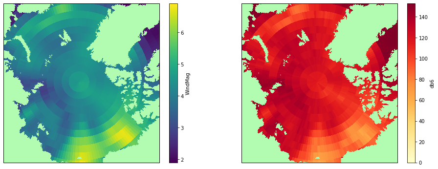

```python
WindMag=xr.open_dataset('WrittenDatasets/WindMag_mask_index.nc')
wma=WindMag['WindMag'].where(WindMag.lat>=60)
wmi=WindMag['db6'].where(WindMag.lat>=60)
cmp0 = matplotlib.cm.get_cmap('viridis')
cmp1 = matplotlib.cm.get_cmap('YlOrRd')
#set land color to light green
cmp0.set_bad(color='#b1fcb1')
cmp1.set_bad(color='#b1fcb1')

fig=plt.figure(figsize=[16,6])
plt.title('Summer 2010')
ax0=plt.subplot(121, projection=ccrs.NorthPolarStereo(0,0))
ax0.set_extent([0, 358.125, 70, 90], crs=ccrs.PlateCarree())
ax0.title.set_text('Average Wind Magnitude (m/s)')
ax1=plt.subplot(122, projection=ccrs.NorthPolarStereo(0,0))
ax1.set_extent([0, 358.125, 70, 90], crs=ccrs.PlateCarree())
ax1.title.set_text('Days Below 6 m/s')

wma.mean('time').where(WindMag.mask==1).plot.pcolormesh(ax=ax0, cmap=cmp0, transform=ccrs.PlateCarree());
wmi.sum('time').where(WindMag.mask==1).plot.pcolormesh(ax=ax1, cmap=cmp1, transform=ccrs.PlateCarree());
plt.savefig('wm_db6')
plt.draw
wma.close()
WindMag.close()
```

```python
#open Dataset of "days Below 6"
ds=xr.open_dataset('WrittenDatasets/WindMag_mask_index.nc')

#Pull Arctic coordinates from the dataset
db6=ds.db6[:,619:719,:]

#calculate the difference between each value in the index
#This should yield -1 when the magnitude moves above 6, 1 when it goes
#below 6, and 0 when it is the same as the previous time
diff=db6.diff('time')

#add a 0 to the array at the previous time for each
#(since Diff calculates w/ respect to the index, yielding an array
#of length n-1 when applied to array of length n
diff1=xr.concat([db6[0],diff], dim='time')

#Sum all elements over time
b1=db6.cumsum('time')

#pull the values for when the wind magnitude moves above 6
b2=b1.where(diff1==-1)

#fill all NaN values w/ previous real value
b3=b2.ffill('time')

#Replace NaN values w/ 0
b4=xr.where(xr.ufuncs.isnan(b3)==True,0,b3)

#Get the difference from the previous drop to yield the "true" value of the drop
b5=b4.diff('time')

#add 0 array to diff once again
b6=xr.concat([xr.zeros_like(db6[0]),b5], dim='time')

#write negative integer value of same value as previous time for when the Wind magnitude
#moves back above 6. This allows the array to return to 0 when such an event happens
b7=xr.where(diff1==-1,-b6,db6)

#apply sum to get index
wmi=b7.cumsum('time')
wmi
```

```
<xarray.DataArray 'db6' (lat: 100, lon: 1440, time: 153)>
array([[[1., 2., 3., ..., 4., 0., 0.],
        [1., 2., 3., ..., 4., 0., 0.],
        [1., 2., 3., ..., 4., 0., 0.],
        ...,
        [0., 1., 2., ..., 4., 5., 6.],
        [0., 1., 2., ..., 4., 5., 6.],
        [0., 1., 2., ..., 4., 5., 6.]],

       [[1., 2., 3., ..., 4., 0., 0.],
        [1., 2., 3., ..., 4., 0., 0.],
        [1., 2., 3., ..., 4., 0., 0.],
        ...,
        [0., 1., 2., ..., 4., 5., 6.],
        [0., 1., 2., ..., 4., 5., 6.],
        [0., 1., 2., ..., 4., 5., 6.]],

       [[1., 2., 3., ..., 4., 0., 0.],
        [1., 2., 3., ..., 4., 0., 0.],
        [1., 2., 3., ..., 4., 0., 0.],
        ...,
        [0., 1., 2., ..., 4., 5., 6.],
        [0., 1., 2., ..., 4., 5., 6.],
        [0., 1., 2., ..., 4., 5., 6.]],

       ...,

       [[1., 2., 3., ..., 0., 0., 0.],
        [1., 2., 3., ..., 0., 0., 0.],
        [1., 2., 3., ..., 0., 0., 0.],
        ...,
        [1., 2., 3., ..., 0., 0., 0.],
        [1., 2., 3., ..., 0., 0., 0.],
        [1., 2., 3., ..., 0., 0., 0.]],

       [[1., 2., 3., ..., 0., 0., 0.],
        [1., 2., 3., ..., 0., 0., 0.],
        [1., 2., 3., ..., 0., 0., 0.],
        ...,
        [1., 2., 3., ..., 0., 0., 0.],
        [1., 2., 3., ..., 0., 0., 0.],
        [1., 2., 3., ..., 0., 0., 0.]],

       [[1., 2., 3., ..., 0., 0., 0.],
        [1., 2., 3., ..., 0., 0., 0.],
        [1., 2., 3., ..., 0., 0., 0.],
        ...,
        [1., 2., 3., ..., 0., 0., 0.],
        [1., 2., 3., ..., 0., 0., 0.],
        [1., 2., 3., ..., 0., 0., 0.]]], dtype=float32)
Coordinates:
    mask     (lat, lon) float32 1.0 1.0 1.0 1.0 1.0 1.0 ... 1.0 1.0 1.0 1.0 1.0
  * lon      (lon) float32 0.125 0.375 0.625 0.875 ... 359.375 359.625 359.875
  * lat      (lat) float32 64.875 65.125 65.375 65.625 ... 89.125 89.375 89.625
  * time     (time) datetime64[ns] 2010-04-01 2010-04-02 ... 2010-08-31
```

```
<function matplotlib.pyplot.show(*args, **kw)>
```

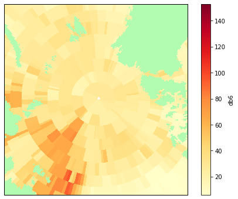

```python
cmp0 = matplotlib.cm.get_cmap('viridis')
cmp1 = matplotlib.cm.get_cmap('YlOrRd')
#set land color to light green
cmp0.set_bad(color='#b1fcb1')
cmp1.set_bad(color='#b1fcb1')
fig=plt.figure(figsize=[8,6])
plt.title('Summer 2010')
ax0=plt.axes(projection=ccrs.NorthPolarStereo(0,0))
ax0.set_extent([0, 358.125, 75, 90], crs=ccrs.PlateCarree())
wmi.max('time').where(wmi.mask==1).plot.pcolormesh(ax=ax0, cmap=cmp1, transform=ccrs.PlateCarree());
plt.show
```

```python
event_index=xr.where(wmi==16,xr.where(wmi.mask==1,1,0),0)
event_index
np.count_nonzero(event_index==1)
```

```
192997
```